# Feature engineering & interpretable for xgboost with board game ratings

2022-03-10

## Explore data

```r
ratings <- read_csv("https://raw.githubusercontent.com/rfordatascience/tidytuesday/master/data/2022/2022-01-25/ratings.csv")
details <- read_csv("https://raw.githubusercontent.com/rfordatascience/tidytuesday/master/data/2022/2022-01-25/details.csv")

head(ratings)
```

```
## # A tibble: 6 x 10
##     num    id name            year  rank average bayes_average users_rated url
##   <dbl> <dbl> <chr>          <dbl> <dbl>   <dbl>         <dbl>       <dbl> <chr>
## 1   105 30549 Pandemic        2008   106    7.59          7.49      108975 /boa~
## 2   189   822 Carcassonne     2000   190    7.42          7.31      108738 /boa~
## 3   428    13 Catan           1995   429    7.14          6.97      108024 /boa~
## 4    72 68448 7 Wonders       2010    73    7.74          7.63       89982 /boa~
## 5   103 36218 Dominion        2008   104    7.61          7.50       81561 /boa~
## 6   191  9209 Ticket to Ride  2004   192    7.41          7.30       76171 /boa~
## # ... with 1 more variable: thumbnail <chr>
```

```r
head(details)
```

```
## # A tibble: 6 x 23
##     num    id primary        description     yearpublished minplayers maxplayers
##   <dbl> <dbl> <chr>          <chr>                   <dbl>      <dbl>      <dbl>
## 1     0 30549 Pandemic       In Pandemic, s~          2008          2          4
## 2     1   822 Carcassonne    Carcassonne is~          2000          2          5
## 3     2    13 Catan          In CATAN (form~          1995          3          4
## 4     3 68448 7 Wonders      You are the le~          2010          2          7
## 5     4 36218 Dominion       &quot;You are ~          2008          2          4
## 6     5  9209 Ticket to Ride With elegantly~          2004          2          5
## # ... with 16 more variables: playingtime <dbl>, minplaytime <dbl>,
## #   maxplaytime <dbl>, minage <dbl>, boardgamecategory <chr>,
## #   boardgamemechanic <chr>, boardgamefamily <chr>, boardgameexpansion <chr>,
## #   boardgameimplementation <chr>, boardgamedesigner <chr>,
## #   boardgameartist <chr>, boardgamepublisher <chr>, owned <dbl>,
## #   trading <dbl>, wanting <dbl>, wishing <dbl>
```

```r
ratings_joined <-
  ratings %>%
  left_join(details, by = "id")

head(ratings_joined)
```

```
## # A tibble: 6 x 32
##   num.x    id name            year  rank average bayes_average users_rated url
##   <dbl> <dbl> <chr>          <dbl> <dbl>   <dbl>         <dbl>       <dbl> <chr>
## 1   105 30549 Pandemic        2008   106    7.59          7.49      108975 /boa~
## 2   189   822 Carcassonne     2000   190    7.42          7.31      108738 /boa~
## 3   428    13 Catan           1995   429    7.14          6.97      108024 /boa~
## 4    72 68448 7 Wonders       2010    73    7.74          7.63       89982 /boa~
## 5   103 36218 Dominion        2008   104    7.61          7.50       81561 /boa~
## 6   191  9209 Ticket to Ride  2004   192    7.41          7.30       76171 /boa~
## # ... with 23 more variables: thumbnail <chr>, num.y <dbl>, primary <chr>,
## #   description <chr>, yearpublished <dbl>, minplayers <dbl>, maxplayers <dbl>,
## #   playingtime <dbl>, minplaytime <dbl>, maxplaytime <dbl>, minage <dbl>,
## #   boardgamecategory <chr>, boardgamemechanic <chr>, boardgamefamily <chr>,
## #   boardgameexpansion <chr>, boardgameimplementation <chr>,
## #   boardgamedesigner <chr>, boardgameartist <chr>, boardgamepublisher <chr>,
## #   owned <dbl>, trading <dbl>, wanting <dbl>, wishing <dbl>
```

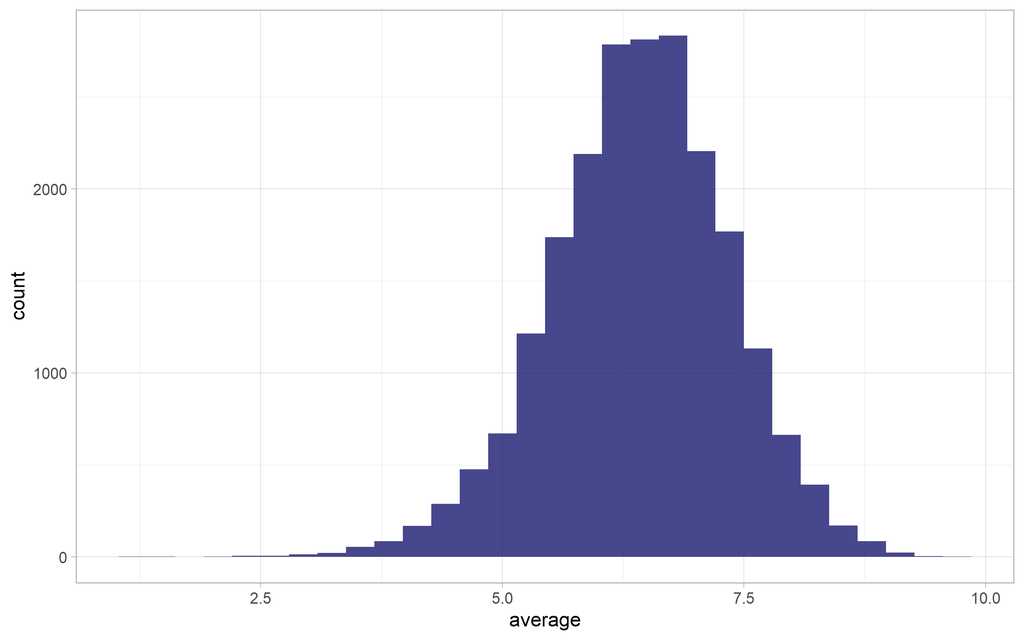

```r
ggplot(ratings_joined, aes(average)) +
  geom_histogram(alpha = 0.8)
```

데이터에서 minage = NA 인 값을 제거하고 min_age를 4등분하여 범주화시킨다. 여기서 보면 minage는 0세 ~ 25세까지 분포하고 있고 NA값을 가진 데이터가 200개가 된다. 이 중 NA를 가진 데이터를 제외하고 cut_number로 4개 범주로 나이대를 구분(0~8세, 8~10세, 10~12세, 12~25세)한 다음 각 나이분포에 대한 평점을 박스로 그렸다.

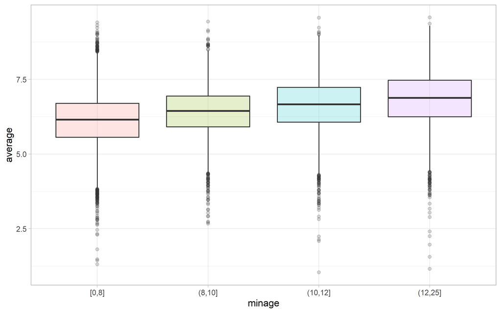

```r
ratings_joined %>%
  filter(!is.na(minage)) %>%
  mutate(minage = cut_number(minage, 4)) %>%
  ggplot(aes(minage, average, fill = minage)) +
  geom_boxplot(alpha = 0.2, show.legend = FALSE)
```

## Tune an xgboost model

select에서 필요한 열을 골라낼 때 matches()를 사용하여 min 혹은 max를 찾아내었음. 그 다음 na.omit()를 이용하여 NA를 포함하고 있는 행을 모두 삭제

```r
library(tidymodels)

preprocess <-
  ratings_joined %>%
  select(name, average, matches("min|max"), boardgamecategory) %>%
  na.omit()

preprocess
```

```
## # A tibble: 21,348 x 8
##    name             average minplayers maxplayers minplaytime maxplaytime minage
##    <chr>              <dbl>      <dbl>      <dbl>       <dbl>       <dbl>  <dbl>
##  1 Pandemic            7.59          2          4          45          45      8
##  2 Carcassonne         7.42          2          5          30          45      7
##  3 Catan               7.14          3          4          60         120     10
##  4 7 Wonders           7.74          2          7          30          30     10
##  5 Dominion            7.61          2          4          30          30     13
##  6 Ticket to Ride      7.41          2          5          30          60      8
##  7 Codenames           7.6           2          8          15          15     14
##  8 Terraforming Ma~    8.42          1          5         120         120     12
##  9 7 Wonders Duel      8.11          2          2          30          30     10
## 10 Agricola            7.93          1          5          30         150     12
## # ... with 21,338 more rows, and 1 more variable: boardgamecategory <chr>
```

```r
game_split <-
  preprocess %>%
  initial_split(strata = average)

game_split
```

```
## <Analysis/Assess/Total>
## <16009/5339/21348>
```

```r
game_train <- training(game_split)
game_test <- testing(game_split)

set.seed(234)
game_folds <- vfold_cv(game_train, strata = average)
game_folds
```

```
## #  10-fold cross-validation using stratification
## # A tibble: 10 x 2
##    splits               id
##    <list>               <chr>
##  1 <split [14407/1602]> Fold01
##  2 <split [14407/1602]> Fold02
##  3 <split [14407/1602]> Fold03
##  4 <split [14408/1601]> Fold04
##  5 <split [14408/1601]> Fold05
##  6 <split [14408/1601]> Fold06
##  7 <split [14408/1601]> Fold07
##  8 <split [14408/1601]> Fold08
##  9 <split [14410/1599]> Fold09
## 10 <split [14410/1599]> Fold10
```

### Preprocessing

```r
library(textrecipes)

# test for making function
# x1 <- game_train %>% sample_n(1) %>% pull(boardgamecategory)
# x1 %>% str_split(", ") %>% map(str_remove_all, "[[:punct:]]") %>% map(str_to_lower)


split_category <- function(x) {
  x %>%
    str_split(", ", ) %>%
    map(str_remove_all, "[[:punct:]]") %>%
    map(str_squish) %>%
    map(str_to_lower) %>%
    map(str_replace_all, " ", "_")
}

game_rec <-
  recipe(average ~ ., data = game_train) %>%
  update_role(name, new_role = "id") %>%
  step_tokenize(boardgamecategory, custom_token = split_category) %>%
  step_tokenfilter(boardgamecategory, max_tokens = 30) %>%
  step_tf(boardgamecategory)

game_prep <- prep(game_rec)
bake(game_prep, new_data = NULL) %>% str()
```

```
## tibble [16,009 x 37] (S3: tbl_df/tbl/data.frame)
##  $ name                                      : Factor w/ 15788 levels "'65: Squad-Level Combat in the Jungles of Vietnam",..: 10886 8635 866 5156 15736 15556 6865 13313 1491 3151 ...
##  $ minplayers                                : num [1:16009] 2 2 4 2 2 2 1 2 2 4 ...
##  $ maxplayers                                : num [1:16009] 6 8 10 6 6 10 8 6 2 16 ...
##  $ minplaytime                               : num [1:16009] 120 60 30 5 60 30 20 60 30 60 ...
##  $ maxplaytime                               : num [1:16009] 120 180 30 30 90 30 20 60 30 60 ...
##  $ minage                                    : num [1:16009] 10 8 12 8 15 6 6 8 8 13 ...
##  $ average                                   : num [1:16009] 5.59 4.37 5.79 5.67 5.8 5.41 5.62 4.31 4.66 5.68 ...
##  $ tf_boardgamecategory_abstract_strategy    : num [1:16009] 0 0 0 0 0 0 0 0 0 0 ...
##  $ tf_boardgamecategory_action_dexterity     : num [1:16009] 0 0 0 0 0 0 1 0 0 0 ...
##  $ tf_boardgamecategory_adventure            : num [1:16009] 0 0 0 0 0 0 0 0 0 0 ...
##  $ tf_boardgamecategory_ancient              : num [1:16009] 0 0 0 0 0 0 0 0 0 0 ...
##  $ tf_boardgamecategory_animals              : num [1:16009] 0 0 0 0 0 0 0 0 0 0 ...
##  $ tf_boardgamecategory_bluffing             : num [1:16009] 0 0 0 0 0 0 0 0 0 0 ...
##  $ tf_boardgamecategory_card_game            : num [1:16009] 0 0 1 1 0 0 0 0 0 0 ...
```

[output cut: 23 more lines]

```r
xgb_spec <-
  boost_tree(
    trees = tune(),
    mtry = tune(),
    min_n = tune(),
    learn_rate = 0.01
  ) %>%
  set_engine("xgboost") %>%
  set_mode("regression")

xgb_spec
```

```
## Boosted Tree Model Specification (regression)
##
## Main Arguments:
##   mtry = tune()
##   trees = tune()
##   min_n = tune()
##   learn_rate = 0.01
##
## Computational engine: xgboost
```

```r
xgb_wf <- workflow(game_rec, xgb_spec)

xgb_wf
```

```
## == Workflow ====================================================================
## Preprocessor: Recipe
## Model: boost_tree()
##
## -- Preprocessor ----------------------------------------------------------------
## 3 Recipe Steps
##
## * step_tokenize()
## * step_tokenfilter()
## * step_tf()
##
## -- Model -----------------------------------------------------------------------
## Boosted Tree Model Specification (regression)
##
## Main Arguments:
##   mtry = tune()
##   trees = tune()
##   min_n = tune()
##   learn_rate = 0.01
##
## Computational engine: xgboost
```

hyperparamter가 있기 때문에 빠르게 찾기 위해 racing approach를 사용하기 위해 `finetune`package를 사용  
finetune::tune_race_anova는 계속해서 에러가 발생. 동일한 현상이 블로그를 보니 다수에게 발생함. 패키지를 모두 업데이트하고 control에 pkgs = c(“stringr”)을 했는데도 계속 발생.  
일단 tune_grid로 돌렸음.

```r
library(finetune)
doParallel::registerDoParallel()

set.seed(234)
xgb_game_rs <-
  tune_grid(
    xgb_wf,
    game_folds,
    grid = 20,
    control = control_grid(verbose = TRUE, pkgs = c("stringr"))
  )

xgb_game_rs
```

```
## # Tuning results
## # 10-fold cross-validation using stratification
## # A tibble: 10 x 4
##    splits               id     .metrics          .notes
##    <list>               <chr>  <list>            <list>
##  1 <split [14407/1602]> Fold01 <tibble [40 x 7]> <tibble [0 x 1]>
##  2 <split [14407/1602]> Fold02 <tibble [40 x 7]> <tibble [0 x 1]>
##  3 <split [14407/1602]> Fold03 <tibble [40 x 7]> <tibble [0 x 1]>
##  4 <split [14408/1601]> Fold04 <tibble [40 x 7]> <tibble [0 x 1]>
##  5 <split [14408/1601]> Fold05 <tibble [40 x 7]> <tibble [0 x 1]>
##  6 <split [14408/1601]> Fold06 <tibble [40 x 7]> <tibble [0 x 1]>
##  7 <split [14408/1601]> Fold07 <tibble [40 x 7]> <tibble [0 x 1]>
##  8 <split [14408/1601]> Fold08 <tibble [40 x 7]> <tibble [0 x 1]>
##  9 <split [14410/1599]> Fold09 <tibble [40 x 7]> <tibble [0 x 1]>
## 10 <split [14410/1599]> Fold10 <tibble [40 x 7]> <tibble [0 x 1]>
```

## Evaluate model

```r
show_best(xgb_game_rs)
```

```
## # A tibble: 5 x 9
##    mtry trees min_n .metric .estimator  mean     n std_err .config
##   <int> <int> <int> <chr>   <chr>      <dbl> <int>   <dbl> <chr>
## 1    17  1702    27 rmse    standard   0.737    10 0.00467 Preprocessor1_Model10
## 2    23  1871    30 rmse    standard   0.738    10 0.00478 Preprocessor1_Model13
## 3    14  1605    40 rmse    standard   0.739    10 0.00489 Preprocessor1_Model08
## 4    25  1986    10 rmse    standard   0.739    10 0.00483 Preprocessor1_Model15
## 5    13  1149     5 rmse    standard   0.739    10 0.00491 Preprocessor1_Model07
```

```r
select_best(xgb_game_rs, "rmse")
```

```
## # A tibble: 1 x 4
##    mtry trees min_n .config
##   <int> <int> <int> <chr>
## 1    17  1702    27 Preprocessor1_Model10
```

hyperparameter를 튜닝했고, 그 결과를 아직 workflow에 반영하지 않았음. 여기까지는 죽 돌린 것이며 거기서 가장 좋은 값이 위의 값임. 이 값이 나오는 mtry, trees, min_n값을 workflow에 반영하여야 함.

last_fit()을 이용하여 test set으로 evaluation을 하여 fitting함. 여기까지 test set을 쓰지 않았음.

```r
xgb_last <-
  xgb_wf %>%
  finalize_workflow(select_best(xgb_game_rs, "rmse")) %>%
  last_fit(game_split)

xgb_last
```

```
## # Resampling results
## # Manual resampling
## # A tibble: 1 x 6
##   splits               id              .metrics .notes   .predictions .workflow
##   <list>               <chr>           <list>   <list>   <list>       <list>
## 1 <split [16009/5339]> train/test spl~ <tibble> <tibble> <tibble>     <workflow>
```

여기까지 한 후 아래에서 볼 수 있는 .estimate값이 test set에 대한 evaluation 결과임. (training set에 대한 값이 아님.)

```r
xgb_last %>% collect_metrics()
```

```
## # A tibble: 2 x 4
##   .metric .estimator .estimate .config
##   <chr>   <chr>          <dbl> <chr>
## 1 rmse    standard       0.732 Preprocessor1_Model1
## 2 rsq     standard       0.370 Preprocessor1_Model1
```

```r
library(vip)

extract_workflow(xgb_last)
```

```
## == Workflow [trained] ==========================================================
## Preprocessor: Recipe
## Model: boost_tree()
##
## -- Preprocessor ----------------------------------------------------------------
## 3 Recipe Steps
##
## * step_tokenize()
## * step_tokenfilter()
## * step_tf()
##
## -- Model -----------------------------------------------------------------------
## ##### xgb.Booster
## Handle is invalid! Suggest using xgb.Booster.complete
## raw: 5.8 Mb
## call:
##   xgboost::xgb.train(params = list(eta = 0.01, max_depth = 6, gamma = 0,
##     colsample_bytree = 1, colsample_bynode = 0.485714285714286,
##     min_child_weight = 27L, subsample = 1, objective = "reg:squarederror"),
##     data = x$data, nrounds = 1702L, watchlist = x$watchlist,
##     verbose = 0, nthread = 1)
## params (as set within xgb.train):
##   eta = "0.01", max_depth = "6", gamma = "0", colsample_bytree = "1", colsample_bynode = "0.485714285714286", min_child_weight = "27", subsample = "1", objective = "reg:squarederror", nthread = "1", validate_parameters = "TRUE"
## callbacks:
##   cb.evaluation.log()
## # of features: 35
## niter: 1702
## nfeatures : 35
## evaluation_log:
##     iter training_rmse
##        1      5.931104
##        2      5.872979
## ---
##     1701      0.692122
##     1702      0.692112
```

```r
xgb_fit <- extract_fit_parsnip(xgb_last)

class(xgb_fit)
```

```
## [1] "_xgb.Booster" "model_fit"
```

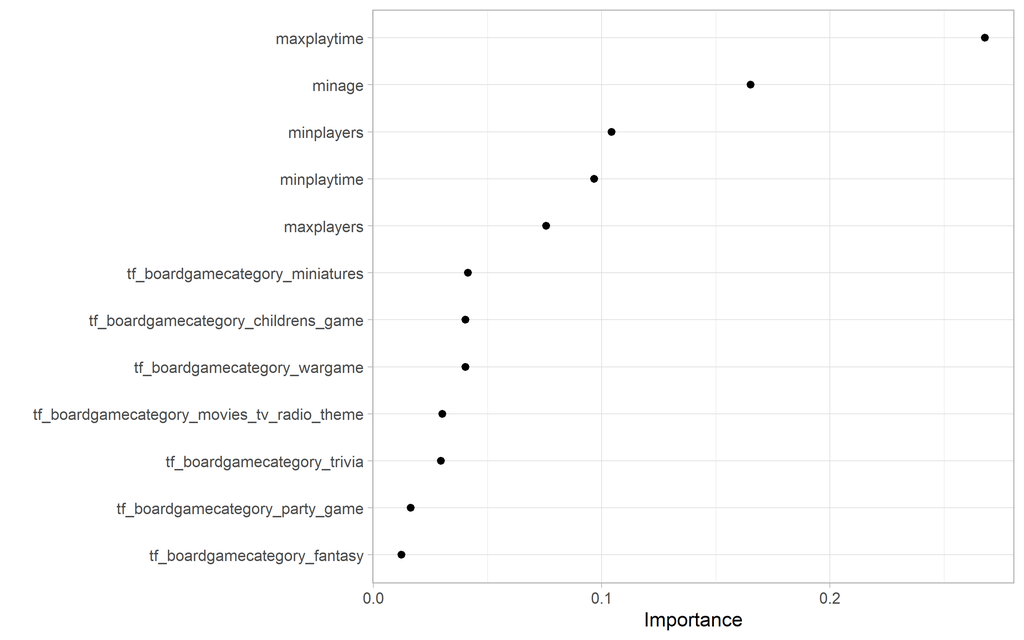

```r
vip(xgb_fit, geom = "point", num_feature = 12)
```

X_train에 matrix가 들어가야 하기 때문에 bake()에 composition 옵션을 이용하여 “matrix” 형태로 받음

```r
library(SHAPforxgboost)

game_shap <-
  shap.prep(
    xgb_model = extract_fit_engine(xgb_fit),
    X_train = bake(game_prep,
                   has_role("predictor"),
                   new_data = NULL,
                   composition = "matrix")
  )

game_shap
```

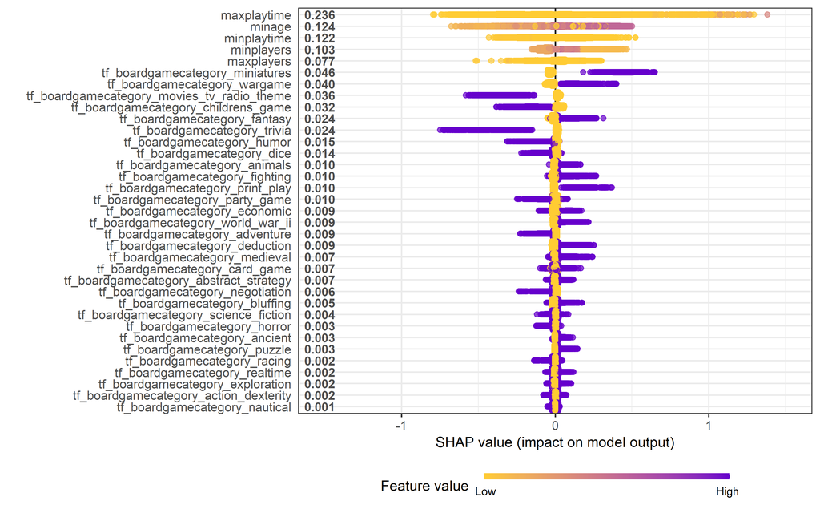

```r
shap.plot.summary(game_shap)
```

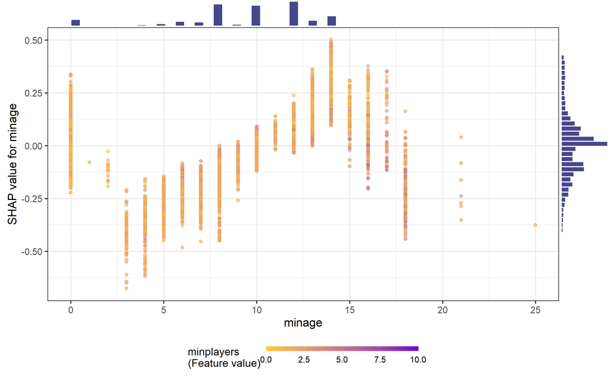

```r
shap.plot.dependence(
  game_shap,
  x = "minage",
  color_feature = "minplayers",
  size0 = 1.2,
  smooth = FALSE, add_hist = TRUE
)
```